# Explore DNA Binding

The GO category DNA binding is enriched for high dNdS genes. The goal here is to align the TanOak genes with other related homologs, build a tree, and see where changes are happening.

Previously I blasted against the NR database, and that was a bit of a mess for building a tree. Will try again, but with BLAST against selected organisms.

```r
library(tidyverse)
library(Biostrings)
library(UpSetR)
library(gplots)
```

## Homolog Sequence retrieval

Start with blastp of `../output/DNA_binding_peps.fa`

Used phyotozome blastp tool against:

- Athaliana_TAIR10_167.proteome;
- Qrubra_v2_1_687.proteome;
- Cdentata_v1_1_673.proteome;
- Gmax_Wm82_a4_v1_508.proteome;
- Ptrichocarpa_v4_1_533.proteome

Results table, retrieved peptides and cDNAs are in `output/DNA_binding_downloads`

## Sequence overlap

Have common sequences been retrieved for the different queries?

```r
hittable <- read_tsv("../output/DNA_binding_downloads/DNA_Binding_Blast.tsv",
                     name_repair = make.names) %>%
  select(-1) %>%
  mutate(gene.name = str_remove(Protein, "\\.[0-9]{1,2}(\\.p)?$"),
         Protein = str_remove(Protein, "\\.p$")) %>% # to match fasta file
  group_by(Query.ID, gene.name) %>%
  slice_max(Bitscore) %>% # one best hit per Query/ Subject
  ungroup()
hittable
```

| Views | Protein | Species | E.value | X..identity | Align.len | Strands | Query.ID | Query.from | Query.to | Target.from | Target.to | Bitscore | X..identical | Positives | Gaps | Query.len | Target.len | gene.name |
| --- | --- | --- | --- | --- | --- | --- | --- | --- | --- | --- | --- | --- | --- | --- | --- | --- | --- | --- |
| phytozome-next.jgi.doe.gov/report/protein/Cdentata_v1_1/Caden.04G071900.1.p | Caden.04G071900.1 | C.dentata v1.1 | 4.11e-25 | 28 | 216 | +/+ | augustus-1014_pilon-processed-gene-5.8 | 10 | 187 | 9 | 224 | 100.9080 | 60 | 110 | 38 | 189 | 274 | Caden.04G071900 |
| phytozome-next.jgi.doe.gov/report/protein/Cdentata_v1_1/Caden.05G147000.1.p | Caden.05G147000.1 | C.dentata v1.1 | 1.52e-25 | 30 | 197 | +/+ | augustus-1014_pilon-processed-gene-5.8 | 9 | 187 | 6 | 202 | 101.6790 | 60 | 106 | 18 | 189 | 249 | Caden.05G147000 |
| phytozome-next.jgi.doe.gov/report/protein/Cdentata_v1_1/Caden.05G147100.1.p | Caden.05G147100.1 | C.dentata v1.1 | 7.08e-22 | 31 | 163 | +/+ | augustus-1014_pilon-processed-gene-5.8 | 45 | 186 | 50 | 210 | 92.0485 | 51 | 92 | 23 | 189 | 262 | Caden.05G147100 |
| phytozome-next.jgi.doe.gov/report/protein/Cdentata_v1_1/Caden.08G012600.3.p | Caden.08G012600.3 | C.dentata v1.1 | 4.60e-13 | 27 | 143 | +/+ | augustus-1014_pilon-processed-gene-5.8 | 2 | 139 | 215 | 357 | 69.3218 | 39 | 72 | 5 | 189 | 446 | Caden.08G012600 |
| phytozome-next.jgi.doe.gov/report/protein/Cdentata_v1_1/Caden.08G012600.1.p | Caden.08G012600.1 | C.dentata v1.1 | 4.93e-13 | 27 | 143 | +/+ | augustus-1014_pilon-processed-gene-5.8 | 2 | 139 | 215 | 357 | 69.3218 | 39 | 72 | 5 | 189 | 448 | Caden.08G012600 |
| phytozome-next.jgi.doe.gov/report/protein/Cdentata_v1_1/Caden.08G012600.2.p | Caden.08G012600.2 | C.dentata v1.1 | 5.21e-13 | 27 | 143 | +/+ | augustus-1014_pilon-processed-gene-5.8 | 2 | 139 | 215 | 357 | 69.3218 | 39 | 72 | 5 | 189 | 439 | Caden.08G012600 |
| phytozome-next.jgi.doe.gov/report/protein/Cdentata_v1_1/Caden.09G089000.1.p | Caden.09G089000.1 | C.dentata v1.1 | 1.14e-51 | 44 | 190 | +/+ | augustus-1014_pilon-processed-gene-5.8 | 5 | 188 | 10 | 196 | 168.7030 | 83 | 123 | 9 | 189 | 243 | Caden.09G089000 |
| phytozome-next.jgi.doe.gov/report/protein/Cdentata_v1_1/Caden.10G121500.1.p | Caden.10G121500.1 | C.dentata v1.1 | 2.40e-18 | 30 | 169 | +/+ | augustus-1014_pilon-processed-gene-5.8 | 12 | 154 | 6 | 174 | 82.0333 | 50 | 78 | 26 | 189 | 230 | Caden.10G121500 |
| phytozome-next.jgi.doe.gov/report/protein/Cdentata_v1_1/Caden.10G192800.1.p | Caden.10G192800.1 | C.dentata v1.1 | 7.28e-90 | 81 | 162 | +/+ | augustus-1014_pilon-processed-gene-5.8 | 17 | 178 | 30 | 178 | 264.6180 | 132 | 139 | 13 | 189 | 212 | Caden.10G192800 |
| phytozome-next.jgi.doe.gov/report/protein/Gmax_Wm82_a4_v1/Glyma.04G254800.12.p | Glyma.04G254800.12 | G.max Wm82.a4.v1 | 2.67e-13 | 28 | 144 | +/+ | augustus-1014_pilon-processed-gene-5.8 | 6 | 144 | 136 | 279 | 69.7070 | 41 | 71 | 5 | 189 | 355 | Glyma.04G254800 |

[output cut: 704 more lines]

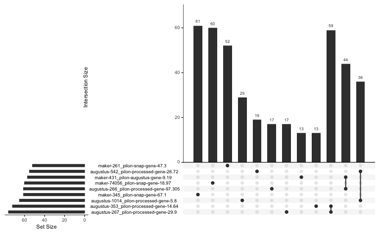

```r
hit.counts <- hittable %>% select(Protein, Query.ID) %>%
  unique() %>%
  table() %>%
  as.data.frame.matrix()

upset(hit.counts, nsets = 10, nintersects = 50)
```

## load Tanoak DNA_binding sequences

```r
tanoak_dna_bind_aa <- readAAStringSet("../output/DNA_binding_peps.fa")
```

## load all Tanoak sequences:

```r
tanoak_aa <- readAAStringSet("../input/blast/TanOak.proteins.fa")
names(tanoak_aa) <- names(tanoak_aa) %>% str_remove("-mRNA-.*")
```

## Load blast sequences

```r
#blast results
blast_peps <- readAAStringSet("../output/DNA_binding_downloads/DNA_Binding_Blast.fas.txt")
names(blast_peps) <- names(blast_peps) %>% str_remove(".*\\|") # get it to match hittable$Protein
```

## original oak Qrob orthologs

```r
blastp_ortho <- read_csv("../output/tanoak_oak_blastp_orthologs.csv") %>%
  mutate(query_id=str_remove(query_id, "-mRNA-.*"))
#read the Oak AA sequences and fix names
qrobAA <- readAAStringSet("../input/blast/Qrob_PM1N_CDS_aa_20161004.fa")
names(qrobAA) <- str_remove(names(qrobAA), " .*") #get rid of extra space and numbers
```

## Qrob homologs

Do blast to get all Qrob homologs

```r
cd ../input/blast
blastp -query ../../output/DNA_binding_peps.fa -db Qrob_PM1N_CDS_aa_20161004.fa -outfmt 7 > ../../output/DNA_binding_Qrob_blast.tsv
```

```r
header <- str_split("query acc.ver, subject acc.ver, % identity, alignment length, mismatches, gap opens, q. start, q. end, s. start, s. end, evalue, bit score", pattern = ", ") %>%
  unlist() %>%
  make.names() %>%
  str_replace(fixed(".."), ".") %>%
  str_replace("X", "pct")

Qrob_hittable <- read_tsv("../output/DNA_binding_Qrob_blast.tsv", comment = "#", col_names = header)
Qrob_hittable
```

| query.acc.ver | subject.acc.ver | pct.identity | alignment.length | mismatches | gap.opens | q.start | q.end | s.start | s.end | evalue | bit.score |
| --- | --- | --- | --- | --- | --- | --- | --- | --- | --- | --- | --- |
| augustus-1014_pilon-processed-gene-5.8 | Qrob_P0685990.2 | 84.293 | 191 | 28 | 1 | 1 | 189 | 1 | 191 | 2.98e-112 | 317.0 |
| augustus-1014_pilon-processed-gene-5.8 | Qrob_P0728520.2 | 45.263 | 190 | 95 | 2 | 5 | 188 | 10 | 196 | 2.56e-55 | 174.0 |
| augustus-1014_pilon-processed-gene-5.8 | Qrob_P0107870.2 | 29.949 | 197 | 120 | 3 | 9 | 187 | 6 | 202 | 4.96e-29 | 107.0 |
| augustus-1014_pilon-processed-gene-5.8 | Qrob_P0160860.2 | 27.876 | 226 | 124 | 5 | 1 | 187 | 7 | 232 | 8.25e-26 | 99.8 |
| augustus-1014_pilon-processed-gene-5.8 | Qrob_P0571140.2 | 28.188 | 149 | 101 | 2 | 22 | 166 | 281 | 427 | 8.50e-13 | 65.5 |
| augustus-1014_pilon-processed-gene-5.8 | Qrob_P0011880.2 | 26.154 | 130 | 95 | 1 | 12 | 140 | 230 | 359 | 7.64e-12 | 62.4 |
| augustus-1014_pilon-processed-gene-5.8 | Qrob_P0332950.2 | 29.730 | 111 | 69 | 1 | 45 | 146 | 247 | 357 | 1.45e-11 | 61.6 |
| augustus-1014_pilon-processed-gene-5.8 | Qrob_P0636380.2 | 24.615 | 130 | 97 | 1 | 12 | 140 | 133 | 262 | 5.23e-10 | 57.0 |
| augustus-1014_pilon-processed-gene-5.8 | Qrob_P0160870.2 | 25.510 | 98 | 51 | 2 | 85 | 160 | 1 | 98 | 3.15e-06 | 45.1 |
| augustus-1014_pilon-processed-gene-5.8 | Qrob_P0200990.2 | 31.250 | 64 | 42 | 1 | 45 | 106 | 190 | 253 | 3.41e-06 | 45.8 |

[output cut: 297 more lines]

## Make a function for extracting homologs and building a tree

```r
get_homologs_tree <- function(ids, filestem, my.hittable=hittable, my.blast_peps=blast_peps, my.blastp_ortho=blastp_ortho, my.Qrob_hittable=Qrob_hittable, my.qrobAA=qrobAA, my.tanoak_aa=tanoak_aa, my.tanoak_dna_bind_aa=tanoak_dna_bind_aa) {


  # get the blast hits
  hits <- my.hittable %>%
    filter(Query.ID %in% ids) %>%
    filter(!duplicated(gene.name))

  homologs <- my.blast_peps[hits$Protein]

  #add tanoak

  targets <- my.tanoak_dna_bind_aa[ids]

  names(targets) <- names(targets) %>% str_c("target_", .)
  homologs <- c(targets, homologs)

  # get the oak protein orthologs

  # filter for those that we want
  oak_orthos <- my.blastp_ortho %>%
    filter(query_id %in% ids)

  qrobAA_orthos <- my.qrobAA[oak_orthos$subject_id]

  #add "ortho" to name to make it clear
  names(qrobAA_orthos) <- str_c(names(qrobAA_orthos), "_ortho")

  #add oak
  homologs <- c(qrobAA_orthos, homologs)


  # now add other Qrob homologs:

  Qrob_hits <- Qrob_hittable %>%
    filter(query.acc.ver %in% ids,
           !duplicated(subject.acc.ver),
           bit.score >= 100) %>%
    pull(subject.acc.ver)

  qrob_homologs <- my.qrobAA[Qrob_hits]

  homologs <- c(homologs, qrob_homologs)

  # Other Tanoak homologs

  if(!dir.exists("_tmp")) dir.create("_tmp")

  writeXStringSet(my.tanoak_dna_bind_aa[ids], "_tmp/tanoak_tmp_aa.fa")

  system("blastp -query _tmp/tanoak_tmp_aa.fa -db ../input/blast/TanOak.proteins.fa -outfmt 7 > _tmp/tmp_vs_Tanoak_blastp.tsv")

  hits_tanoak <- read_tsv("_tmp/tmp_vs_Tanoak_blastp.tsv",
                          comment = "#",
                          col_names = header) %>%
    filter(evalue < 1e-5,
           !subject.acc.ver %in% unique(query.acc.ver),
           !duplicated(subject.acc.ver)) %>%
    mutate(subject.acc.ver = str_remove(subject.acc.ver, "-mRNA-.*"))

  # extract the TanOak sequences and add

  tanoak_paralogs <- my.tanoak_aa[hits_tanoak$subject.acc.ver]
  homologs <- c(homologs, tanoak_paralogs)

  # Prune short sequences
  med_length <- median(nchar(homologs))
  homologs <- homologs[nchar(homologs) > 0.5*med_length & nchar(homologs) < 2*med_length]


  # write out the table
  names(homologs) <- str_remove(names(homologs), ".*\\|")
  homologs <- homologs[!duplicated(names(homologs))]
  writeXStringSet(homologs, "_tmp/tmp_tanoak_orthos.fa")

  ## align!
  if(!(dir.exists("trees"))) dir.create("trees")
  system2("mafft",
          args = c("--thread 4", "--localpair", "--maxiterate 1000", "--reorder", "_tmp/tmp_tanoak_orthos.fa"),
          stdout=str_c("../output/trees/", filestem, "_orthos_aligned.fa"))

  # prune alignment

  aligned <- readAAMultipleAlignment(str_c("../output/trees/", filestem, "_orthos_aligned.fa"))
  aligned <- maskGaps(aligned, min.fraction=0.50, min.block.width=10)
  maskedratio(aligned)

  writeXStringSet(as(aligned, "AAStringSet"), str_c("../output/trees/", filestem, "_orthos_aligned_pruned.fa"))

  # build tree
 # system2("FastTreeMP", args=str_c("../output/trees/", filestem, "_orthos_aligned_pruned.fa"),
          #stdout = str_c("../output/trees/", filestem, "_orthos.tre"))

system2("FastTree", args=str_c("../output/trees/", filestem, "_orthos_aligned_pruned.fa"),
          stdout = str_c("../output/trees/", filestem, "_orthos.tre"))
}
```

```r
get_homologs_tree(ids = c("augustus-1014_pilon-processed-gene-5.8",
                          "augustus-542_pilon-processed-gene-26.72"),
                  filestem="1014_542_RAS1")

get_homologs_tree(ids = c("maker-431_pilon-augustus-gene-9.19", "augustus-266_pilon-processed-gene-97.305"), filestem = "431_266_ATHB-7")

get_homologs_tree(ids = "maker-74056_pilon-snap-gene-18.97",
                  filestem = "74056_WRK41")

get_homologs_tree(ids = "maker-261_pilon-snap-gene-47.3",
                  filestem = "261_WRKY40")

get_homologs_tree(ids = "maker-345_pilon-snap-gene-67.1",
                  filestem = "345_WRKY11")

get_homologs_tree(ids = c("augustus-353_pilon-processed-gene-14.64", "augustus-267_pilon-processed-gene-29.9"),
                  filestem = "353_HSF2_3")
```

See trees on iTol

## Look at alignments of orthologs

```r
# get close orthologs from oak and chestnut

get_orthos <- function(ids, filestem, my.hittable=hittable, my.blast_peps=blast_peps, my.blastp_ortho=blastp_ortho, my.Qrob_hittable=Qrob_hittable, my.qrobAA=qrobAA, my.tanoak_aa=tanoak_aa, my.tanoak_dna_bind_aa=tanoak_dna_bind_aa) {


  # get the blast hits
  hits <- my.hittable %>%
    filter(Query.ID %in% ids) %>%
    filter(!duplicated(gene.name))

  homologs <- my.blast_peps[hits$Protein]

  #add tanoak

  targets <- my.tanoak_dna_bind_aa[ids]

  names(targets) <- names(targets) %>% str_c("target_", .)
  homologs <- c(targets, homologs)

  # get the oak protein orthologs

  # filter for those that we want
  oak_orthos <- my.blastp_ortho %>%
    filter(query_id %in% ids)

  qrobAA_orthos <- my.qrobAA[oak_orthos$subject_id]

  #add "ortho" to name to make it clear
  names(qrobAA_orthos) <- str_c(names(qrobAA_orthos), "_ortho")

  #add oak
  homologs <- c(qrobAA_orthos, homologs)


  # now add other Qrob homologs:

  Qrob_hits <- Qrob_hittable %>%
    filter(query.acc.ver %in% ids,
           !duplicated(subject.acc.ver),
           bit.score >= 100) %>%
    pull(subject.acc.ver)

  qrob_homologs <- my.qrobAA[Qrob_hits]

  homologs <- c(homologs, qrob_homologs)

  # Other Tanoak homologs

  if(!dir.exists("_tmp")) dir.create("_tmp")

  writeXStringSet(my.tanoak_dna_bind_aa[ids], "_tmp/tanoak_tmp_aa.fa")

  system("blastp -query _tmp/tanoak_tmp_aa.fa -db ../input/blast/TanOak.proteins.fa -outfmt 7 > _tmp/tmp_vs_Tanoak_blastp.tsv")

  hits_tanoak <- read_tsv("_tmp/tmp_vs_Tanoak_blastp.tsv",
                          comment = "#",
                          col_names = header) %>%
    filter(evalue < 1e-5,
           !subject.acc.ver %in% unique(query.acc.ver),
           !duplicated(subject.acc.ver)) %>%
    mutate(subject.acc.ver = str_remove(subject.acc.ver, "-mRNA-.*"))

  # extract the TanOak sequences and add

  tanoak_paralogs <- my.tanoak_aa[hits_tanoak$subject.acc.ver]
  homologs <- c(homologs, tanoak_paralogs)

  # Prune short sequences
  med_length <- median(nchar(homologs))
  homologs <- homologs[nchar(homologs) > 0.5*med_length & nchar(homologs) < 2*med_length]


ruba_dentata_ortho_names <- hits %>% filter(Species %in% c("C.dentata v1.1", "Q.rubra v2.1") ) %>%
  group_by(Species) %>%
  slice_max(Bitscore) %>%
  pull(Protein)

orthos_small <- c(targets, qrobAA_orthos, homologs[ruba_dentata_ortho_names])

writeXStringSet(orthos_small, "_tmp/tmp_tanoak_small_orthos.fa")

system2("mafft",
        args = c("--thread 4", "--localpair", "--maxiterate 1000", "--reorder", "_tmp/tmp_tanoak_small_orthos.fa"),
        stdout=str_c("../output/trees/", filestem, "_small_orthos_aligned.fa"))

file.remove(dir("_tmp", pattern=".*", full.names = TRUE))
}
```

```r
gene_table <- tibble(
  id=c("augustus-1014_pilon-processed-gene-5.8",
                          "augustus-542_pilon-processed-gene-26.72",
       "maker-431_pilon-augustus-gene-9.19",
       "augustus-266_pilon-processed-gene-97.305",
       "maker-74056_pilon-snap-gene-18.97",
       "maker-261_pilon-snap-gene-47.3",
       "maker-345_pilon-snap-gene-67.1",
       "augustus-353_pilon-processed-gene-14.64",
       "augustus-267_pilon-processed-gene-29.9"),
  stem=c("1014_RAS1",
         "542_RAS1",
         "431_ATHB-7",
         "266_ATHB-7",
         "74056_WRK41",
         "261_WRKY40",
         "345_WRKY11",
         "353_HSFA2",
         "267_HSFA3"
         )
)

walk2(gene_table$id, gene_table$stem, get_orthos)
```

[output not shown]

[output cut: 657 more lines]

[output not shown]

## small alignment notes

1014 and 542_RAS1: Qurub orthologs aren’t right (Removed)

1014: Not clear that we have the right Caden ortholog

353_HSFA2: Qrob orthlog looks to have annotation error; sequence diverges at 3’ end. (Editted to truncate)

## Calculate divergence from Caden

| file | Tanoak | Qurub | Qrob |
| --- | --- | --- | --- |
| 261_WRKY40_small_orthos_aligned.fa | 14 | 15 | 19 |
| 266_ATHB-7_small_orthos_aligned.fa | 13 | 10 | 12 |
| 267_HSFA3_small_orthos_aligned.fa | 39 | 51 | 60 |
| 345_WRKY11_small_orthos_aligned.fa | 13 | 16 | 12 |
| 353_HSFA2_small_orthos_aligned.fa | 16 | 17 | 16 |
| 431_ATHB-7_small_orthos_aligned.fa | 8 | 11 | 9 |
| 542_RAS1_small_orthos_aligned.fa | 19 | NA | 15 |
| 74056_WRK41_small_orthos_aligned.fa | 11 | 11 | 12 |